# Background separation for various platinum-based chemotherapeutics

### Stacked bar charts showing target and background signature exposures

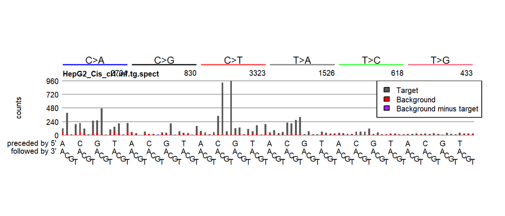

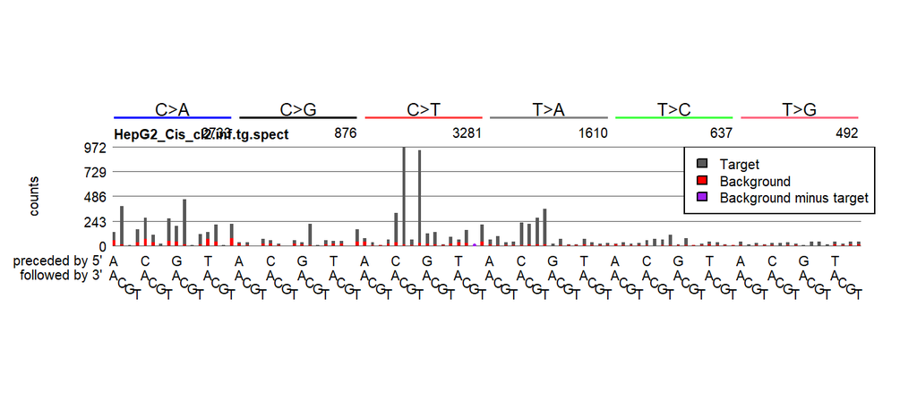

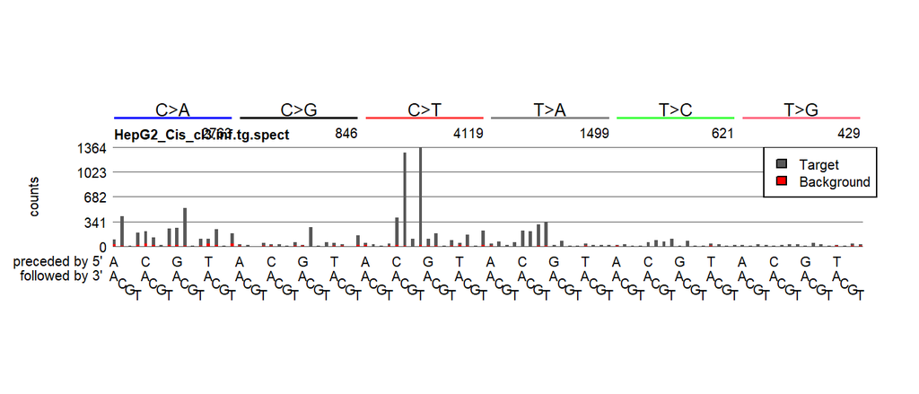

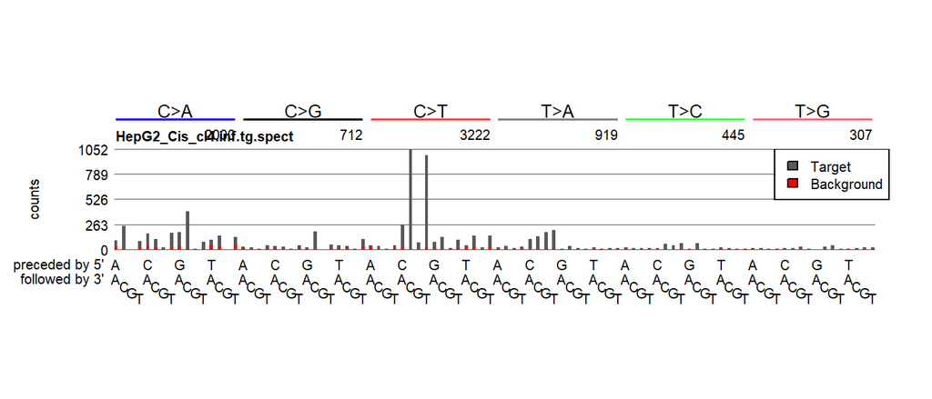

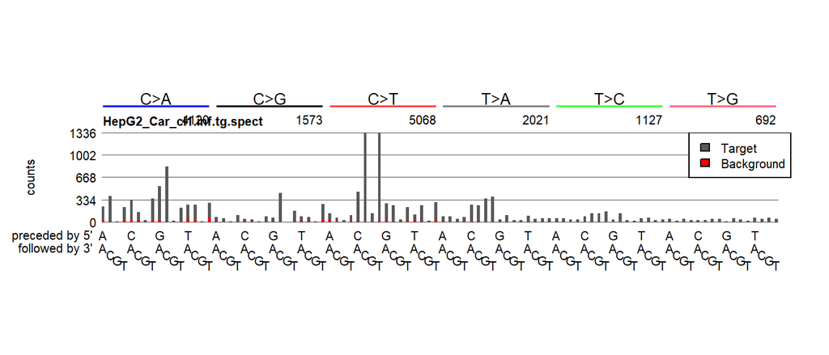

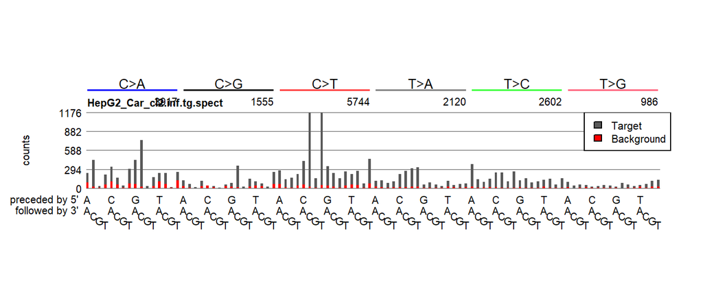

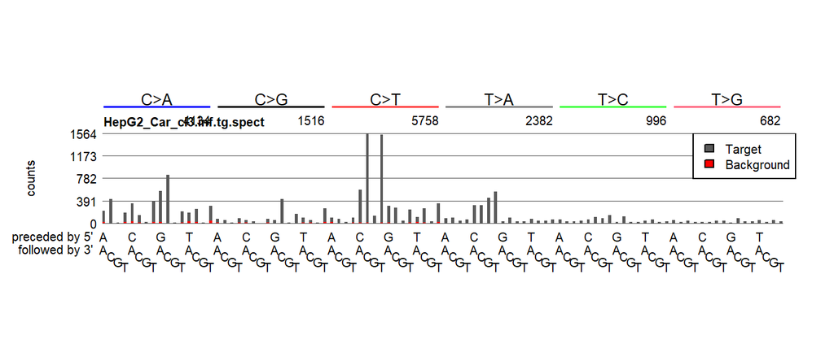

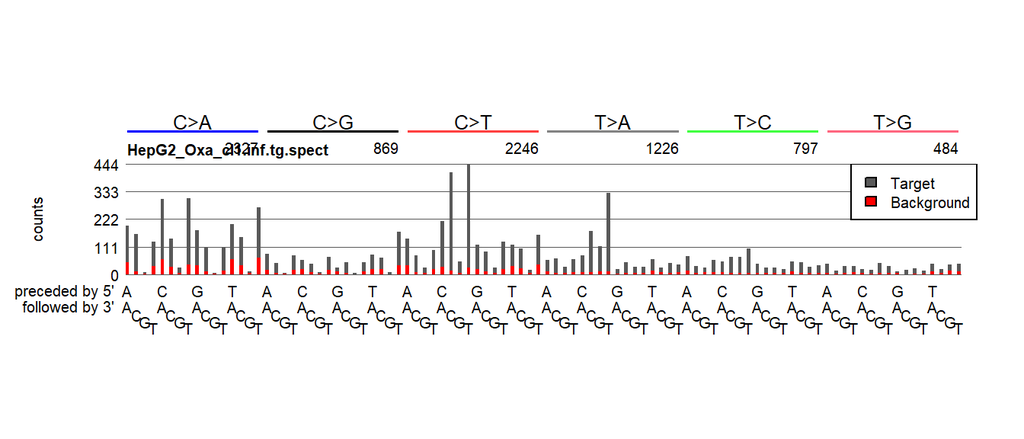

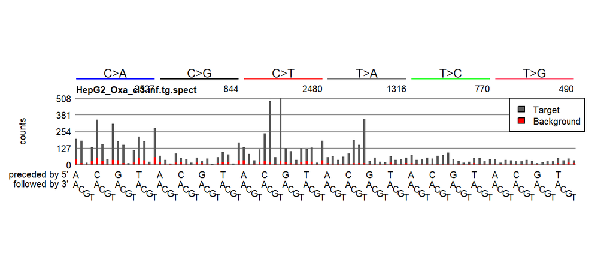

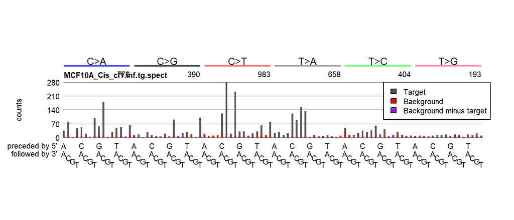

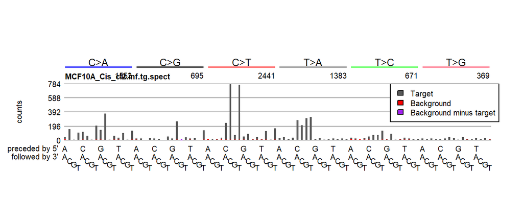

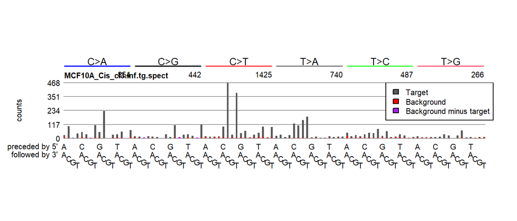

[7 more figures not shown]

```r
par(mfrow = c(1, 1))
par(mar = c(7, 5, 7, 2))
par(cex = 0.8)
par(cex.main = 1.4)
for (test.name in names(all.separated)) {

  info <- all.separated[[test.name]]
  bg.spectra <- info$inferred.bg.spectra
  ta.spectra <- info$inferred.target.spectra

  for (colnum in 1:ncol(bg.spectra)) {
    Plot1StackedSpectrum(
      background.spectrum = bg.spectra[ , colnum, drop = FALSE],
      target.spectrum     = ta.spectra[ , colnum, drop = FALSE])
  }
}
```

## Similarities across combined partial target spectra and inferred signatures

```r
remove.to.dot <- function(x, times) {
  for (ii in 1:times) {
    x <- sub("[^\\.]*\\.", "", x = x, perl = TRUE)
  }
  return(x)
}
```

```r
inferred.spectra.list <- lapply(all.separated, `[[`, "inferred.target.spectra")
all.target.spectra <- do.call(cbind, inferred.spectra.list)

# Clean up the columb names
colnames(all.target.spectra) <-
  sub(".inf.tg.spect", "",
      x = colnames(all.target.spectra),
      fixed = TRUE)
colnames(all.target.spectra) <- remove.to.dot(colnames(all.target.spectra), 3)
```

### Heatmap of cosine similarities

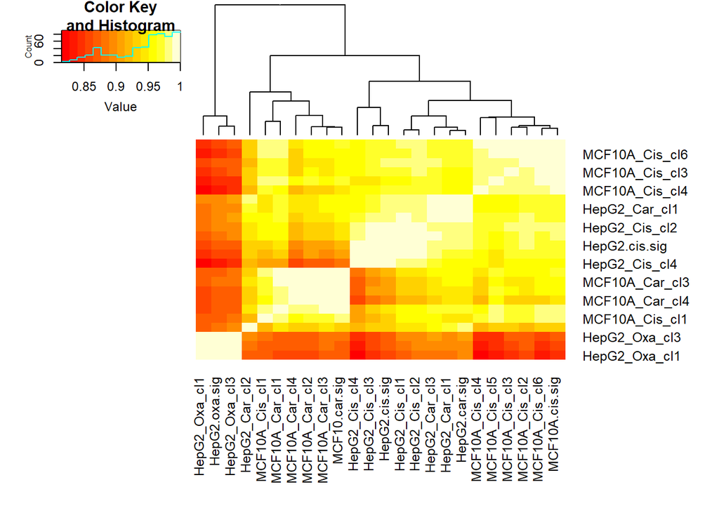

```r
all.target.sig.list <- lapply(all.separated, `[[`, "inferred.target.sig.as.catalog")

all.target.sigs <- do.call(cbind, all.target.sig.list)

grist <- cbind(
  ICAMS::TransformCatalog(all.target.spectra,
                          target.catalog.type = "counts.signature"),
  all.target.sigs)

cosine.sim <- suppressMessages(
  philentropy::distance(t(grist), method = "cosine"))

rownames(cosine.sim) <- colnames(grist)
colnames(cosine.sim) <- colnames(grist)
gplots::heatmap.2(x = cosine.sim,
                  dendrogram = "column",
                  margins = c(9, 9),
                  cex.axis = 0.5,
                  symm = TRUE,
                  trace = "none")
```

### Principal components analysis

#### PCA with signatures and partial spectra

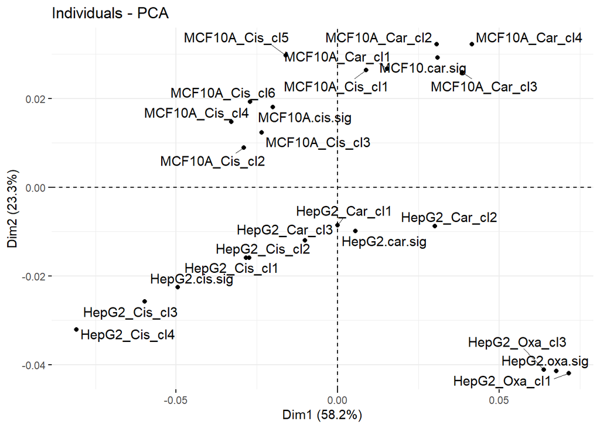

```r
pc <- prcomp(t(grist), center = TRUE, scale = FALSE, retx = TRUE)

factoextra::fviz_pca_ind(pc, repel = TRUE)
```

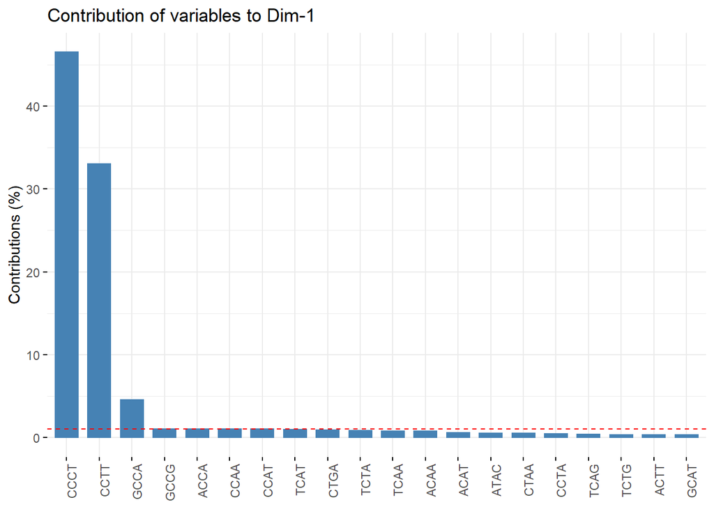

```r
factoextra::fviz_contrib(
  pc, choice   = "var",
  top          = 20,
  xtickslab.rt = 90)
```

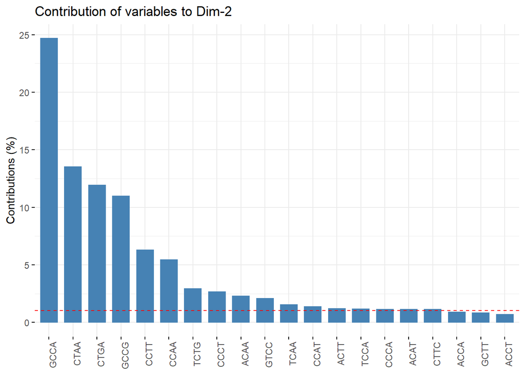

```r
factoextra::fviz_contrib(
  pc, choice   = "var",
  top          = 20,
  axes         = 2,
  xtickslab.rt = 90)
```

#### PCA on signatures only

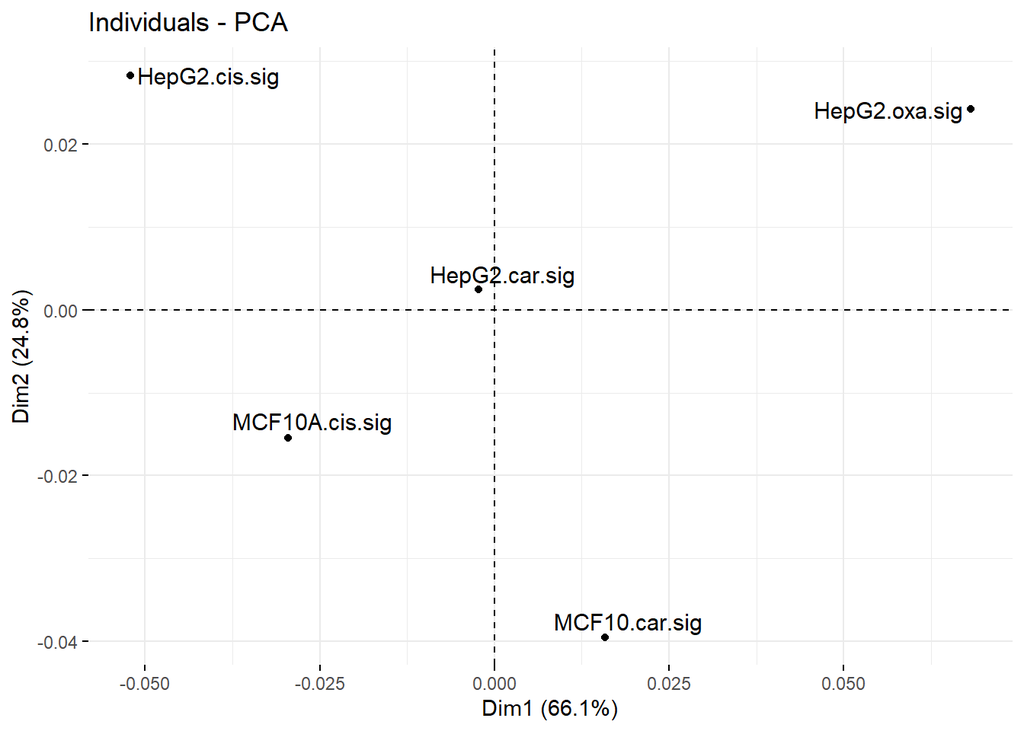

```r
pc <- prcomp(t(all.target.sigs), center = TRUE, scale = FALSE, retx = TRUE)

factoextra::fviz_pca_ind(pc, repel = TRUE)
```

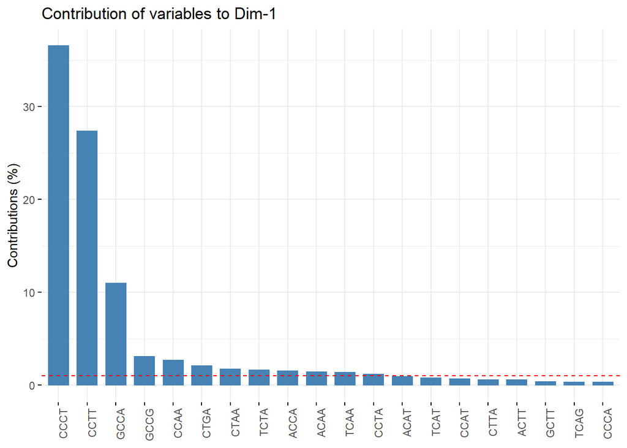

```r
factoextra::fviz_contrib(
  pc, choice   = "var",
  top          = 20,
  xtickslab.rt = 90)
```

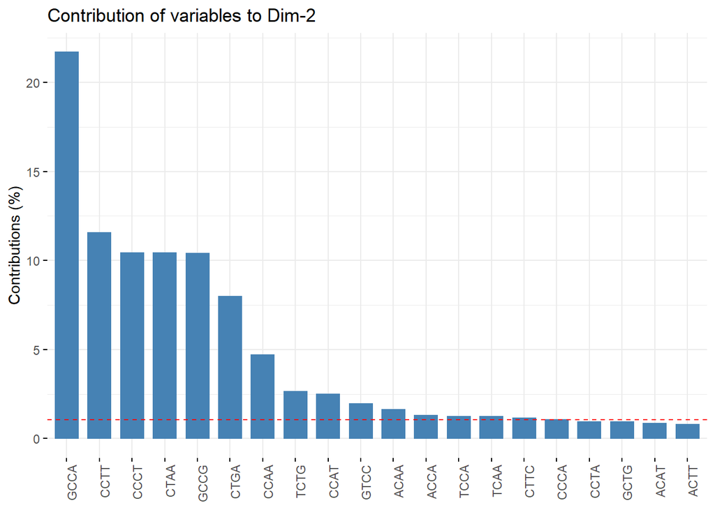

```r
factoextra::fviz_contrib(
  pc, choice   = "var",
  top          = 20,
  axes         = 2,
  xtickslab.rt = 90)
```

#### PCA without oxaliplatin

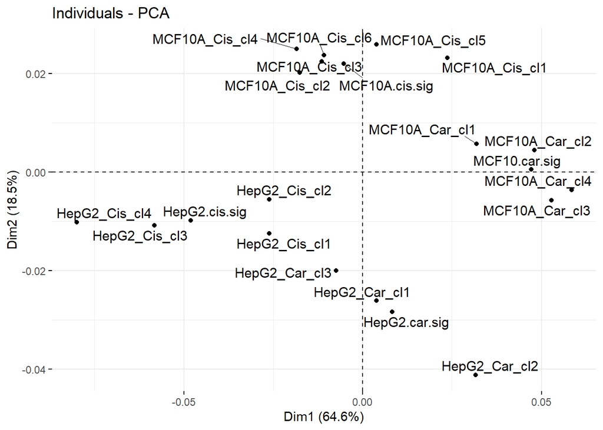

```r
ox.indices <- grep("oxa", colnames(grist), ignore.case = TRUE)
grist.no.ox <- grist[ , -ox.indices]
pc <- prcomp(t(grist.no.ox), center = TRUE, scale = FALSE, retx = TRUE)

factoextra::fviz_pca_ind(pc, repel = TRUE)
```

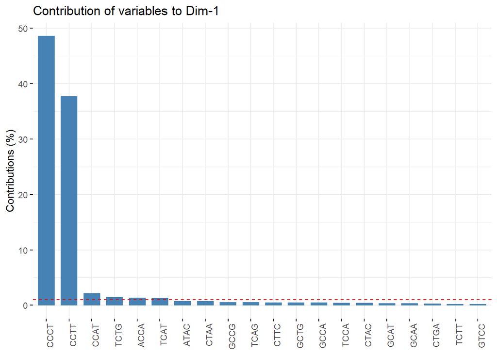

```r
factoextra::fviz_contrib(
  pc, choice     = "var",
  xtickslab.rt   = 90,
  top            = 20)
```

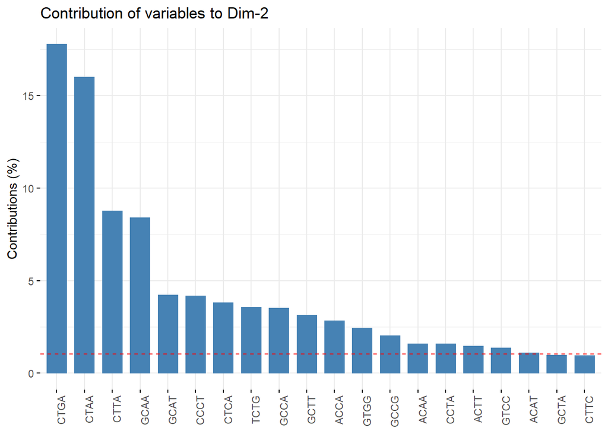

```r
factoextra::fviz_contrib(
  pc, choice     = "var",
  xtickslab.rt   = 90,
  top            = 20,
  axes           = 2)
```

## How well do combinations of COSMIC signatures SBS31 and SBS35 reconstruct experimental signatures?

### Set up numerical optimizaiton for maximum cosine similarity

```r
sbs31 <- PCAWG7::signature$genome$SBS96[ , "SBS31"]
sbs35 <- PCAWG7::signature$genome$SBS96[ , "SBS35"]

one.opt <- function(sig, method = "cosine", invert = -1) {

  sig <- as.vector(sig)

  my.obj.fn <- function(coef) {
    recon <- coef[1]*sbs31 + coef[2]*sbs35
    return(
      suppressMessages(
        invert * philentropy::distance(
          rbind(recon, sig), method = method)))
  }

  g_ineq <- function(coef) {
    abs(1 - sum(coef))
  }

  retval <- nloptr::nloptr(
    x0          = c(0.5, 0.5),
    eval_f      = my.obj.fn,
    eval_g_ineq = g_ineq,
    lb          = c(0, 0),
    ub          = c(1, 1),
    opt         = list(
      algorithm = "NLOPT_LN_COBYLA",
      maxeval   = 2000,
      xtol_rel  = 1e-6,
      xtol_abs  = 1e-7)
  )

  retval <- list(similarity = invert * retval$objective,
              coef = retval$solution / sum(retval$solution))

  return(retval)

}
```

### Results of reconstruction from SBS31 and SBS35

```r
t(
  as.data.frame(
    lapply(
      all.target.sig.list,
      function(x) { ret <- one.opt(x)
      names(ret$coef) <- c("sbs31", "sbs35")
      return(c(cos.sim = ret$similarity, ret$coef))})
  ))
```

```
##                cos.sim sbs31 sbs35
## HepG2.cis.sig     0.97  0.70  0.30
## HepG2.car.sig     0.94  0.63  0.37
## HepG2.oxa.sig     0.90  0.42  0.58
## MCF10A.cis.sig    0.96  0.53  0.47
## MCF10.car.sig     0.91  0.35  0.65
```

Conclusion: the experimental cisplatin signatures are best reconstructed by combinations of SBS31 and SBS35, the carboplatin signatures are constructed pretty well, and oxaliplatin is not reconstructed as well. Hypothesis: The relative contributions of SBS31 and SBS35 may vary across samples. Can check to see if this is the case for the individual cell line partial spectra.